# Part 1 - R introduction

In this introduction to R, we will present the main R concepts, by introducing R variables, vectors, matrices, lists, functions and packages.  
You could also have a look at the following online resources:  
https://www.youtube.com/watch?v=o0Y478jOjGk  
https://www.youtube.com/watch?v=u1r5XTqrCTQ  
https://campus.datacamp.com/  
http://tryr.codeschool.com/

# Variables

In R, we have two main types of values: numeric values and characters.

```r
1
```

```
## [1] 1
```

```r
"text"
```

```
## [1] "text"
```

We can save these values in variables, so we can easily access them later.

```r
a <- 1
a
```

```
## [1] 1
```

And re-use them :

```r
a + a
```

```
## [1] 2
```

Exercises:

1. Assign a number of your choice to “b”

```r
b <- 7
```

2. Show what’s in b

```r
b
```

```
## [1] 7
```

3. Multiply a by 2

```r
a * 2
```

```
## [1] 2
```

4. Add 10 to a

```r
a + 10
```

```
## [1] 11
```

5. Assign your name to an object called name

```r
name <- "Helena"
```

# Vectors

Vectors contain several values:

```r
b <- 1:10
```

You can concatenate these values with the “c” function:

```r
c(b, b)
```

```
##  [1]  1  2  3  4  5  6  7  8  9 10  1  2  3  4  5  6  7  8  9 10
```

You can also apply mathematical formulas to them:

```r
b + b
```

```
##  [1]  2  4  6  8 10 12 14 16 18 20
```

Exercises on vectors:

6. Concatenate a and b

```r
c(a, b)
```

```
##  [1]  1  1  2  3  4  5  6  7  8  9 10
```

7. Concatenate your name and a

```r
c(name, a)
```

```
## [1] "Helena" "1"
```

8. Add a to b

```r
a + b
```

```
##  [1]  2  3  4  5  6  7  8  9 10 11
```

# Functions

Many functions exist in R, and greatly simplify your life:

```r
(1 + 2 + 3 + 4 + 5 + 6 + 7 + 8 + 9 + 10)/10
```

```
## [1] 5.5
```

```r
mean(b)
```

```
## [1] 5.5
```

The head function shows the 6 first elements of any object.  
The median function computes the median of a vector.  
The length function returns the length of a vector.

```r
head(b)
```

```
## [1] 1 2 3 4 5 6
```

```r
head(b, n=3)
```

```
## [1] 1 2 3
```

```r
median(b)
```

```
## [1] 5.5
```

```r
length(b)
```

```
## [1] 10
```

# Matrices

Matrices can be compared to tables: they are two dimensional and can contain numbers, characters…

```r
load("../inst/extdata/cyto.RData")
cyto
```

```
##             FSC-A     SSC-A      CD45      CD19      CD34      CD56
## cell_1   96985.98  34853.85 160.62489 111.52325  60.59250  75.91315
## cell_2   88143.30  22730.01 146.89993 109.37424  60.74403  66.13155
## cell_3   92953.35  31651.34  46.90078  64.03857  76.36395  82.21494
## cell_4   78595.02  51510.99 176.39761  63.25624  64.01659 114.98014
## cell_5  109199.79  60020.60 159.90495  63.29745  87.70644  88.29176
## cell_6  136586.52 130294.78 162.73160  59.74005  88.22612 140.49802
## cell_7   86250.78  25582.85  14.60138  63.21502  78.34427  65.37292
## cell_8    6391.98   4621.63  99.39405  58.45350  55.43047  65.70305
## cell_9   16286.76   7108.74 101.62800  67.55399 148.54910  77.11388
## cell_10  91409.22  76663.14 195.31946  59.94742  79.83633  80.57721
```

We can check the number of rows and columns in the cyto object:

```r
nrow(cyto)
```

```
## [1] 10
```

```r
ncol(cyto)
```

```
## [1] 6
```

# Indexing

A specific column of a matrix can be selected by its number:

```r
fcs_a <- cyto[, 1]
fcs_a
```

```
##    cell_1    cell_2    cell_3    cell_4    cell_5    cell_6    cell_7
##  96985.98  88143.30  92953.35  78595.02 109199.79 136586.52  86250.78
##    cell_8    cell_9   cell_10
##   6391.98  16286.76  91409.22
```

Or the column can also be selected by typing its column name directly:

```r
cd45 <- cyto[, "CD45"]
cd45
```

```
##    cell_1    cell_2    cell_3    cell_4    cell_5    cell_6    cell_7
## 160.62489 146.89993  46.90078 176.39761 159.90495 162.73160  14.60138
##    cell_8    cell_9   cell_10
##  99.39405 101.62800 195.31946
```

Or we can select a specific row:

```r
cell2 <- cyto[2, ]
cell2
```

```
##       FSC-A       SSC-A        CD45        CD19        CD34        CD56
## 88143.29688 22730.00977   146.89993   109.37424    60.74403    66.13155
```

We can also select several columns of a matrix, with the “c” function:

```r
cyto[, c(1, 2)]
```

```
##             FSC-A     SSC-A
## cell_1   96985.98  34853.85
## cell_2   88143.30  22730.01
## cell_3   92953.35  31651.34
## cell_4   78595.02  51510.99
## cell_5  109199.79  60020.60
## cell_6  136586.52 130294.78
## cell_7   86250.78  25582.85
## cell_8    6391.98   4621.63
## cell_9   16286.76   7108.74
## cell_10  91409.22  76663.14
```

Exercises on matrices:

9. Show the 2 first rows of the cyto matrix

```r
cyto[c(1,2),]
```

```
##           FSC-A    SSC-A     CD45     CD19     CD34     CD56
## cell_1 96985.98 34853.85 160.6249 111.5233 60.59250 75.91315
## cell_2 88143.30 22730.01 146.8999 109.3742 60.74403 66.13155
```

10. Show the FSC-A value of the first cell

```r
cyto[1, "FSC-A"]
```

```
## [1] 96985.98
```

# Lists

Lists in R can be compared to vectors, which can contain various objects:

```r
random_numbers <- c(1, 2, 3, 7)
random_letters <- c("A", "B", "C", "Z")
```

```r
my_list <- list(my_numbers = random_numbers,
                my_letters = random_letters)
my_list
```

```
## $my_numbers
## [1] 1 2 3 7
##
## $my_letters
## [1] "A" "B" "C" "Z"
```

The different items of a list can then be accessed by using the “$” and typing their name directly:

```r
my_list$my_numbers
```

```
## [1] 1 2 3 7
```

Exercises on lists:

11. Create a list containing your name, and job:

```r
my_list <- list(name = name, job = "bioinformatician")
my_list
```

```
## $name
## [1] "Helena"
##
## $job
## [1] "bioinformatician"
```

# Packages

Packages contain sets of useful functions, which can be installed, loaded, and then used in R. A package needs to be installed only once on your computer:

```r
# install.packages(Rtsne)
```

But needs to be loaded every time you wish to use it:

```r
library(Rtsne)
```

The functions of an installed package can then be used. They often need the user to set parameters:

```r
# tsne <- Rtsne(cyto)
```

This line would generate an error, we need to lower the perplexity as we only have 10 cells.

```r
tsne <- Rtsne(cyto, perplexity = 2)
tsne$Y
```

```
##             [,1]       [,2]
##  [1,]  -37.99956  -91.08159
##  [2,]   48.92439 -109.99895
##  [3,]  -13.06376  -80.39086
##  [4,]  -37.29171  -38.57031
##  [5,] -123.76114   22.73071
##  [6,]  -77.48832   59.46613
##  [7,]   29.01285 -129.06197
##  [8,]  164.97006  166.39946
##  [9,]  142.44605  179.34354
## [10,]  -95.74885   21.16385
```

You can always ask help to R, if you wish to know how a function works:

```r
?Rtsne
```

Once we have the coordinates of the cells in the new tsne space, we can plot them with the plot function:

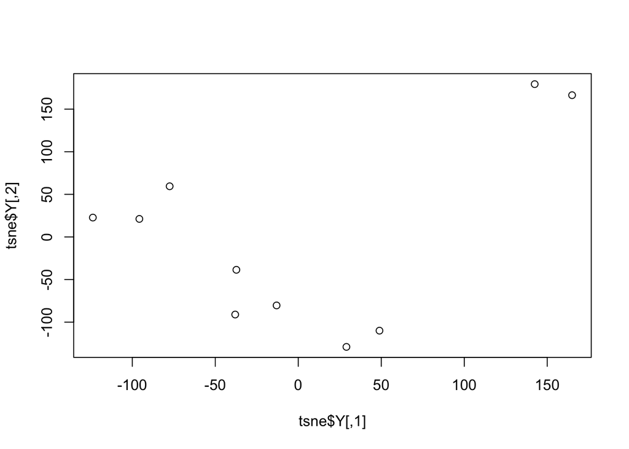

```r
plot(tsne$Y)
```

# Exports

Objetcs that were created in R can be exported in many formats to be shared.

We can for instance save our result of tsne in an excel file, using the write.xlsx function from the openxlsx package:

```r
library(openxlsx)

write.xlsx(tsne$Y, file = "tsne_result.xlsx")
```

```
## Note: zip::zip() is deprecated, please use zip::zipr() instead
```

We can also, on the other hand, import excel files into R:

```r
imported_tsne <- read.xlsx("tsne_result.xlsx")
imported_tsne
```

```
##            V1         V2
## 1   -37.99956  -91.08159
## 2    48.92439 -109.99895
## 3   -13.06376  -80.39086
## 4   -37.29171  -38.57031
## 5  -123.76114   22.73071
## 6   -77.48832   59.46613
## 7    29.01285 -129.06197
## 8   164.97006  166.39946
## 9   142.44605  179.34354
## 10  -95.74885   21.16385
```

Plots can be exported from R, by opening a pdf environement. The pdf function opens a new pdf file. All the following plotting commands will automatically be plotted in the pdf file. The dev.off() function closes the pdf.

```r
pdf("tsne_plot.pdf")
plot(tsne$Y)
dev.off()
```

Exercises on plots:

12. The plot function has many useful arguments (xlab to change the xaxis’ name, ylab to change the yaxis’ name, main to change the title…) Play with these parameters until you generate a tsne plot you like

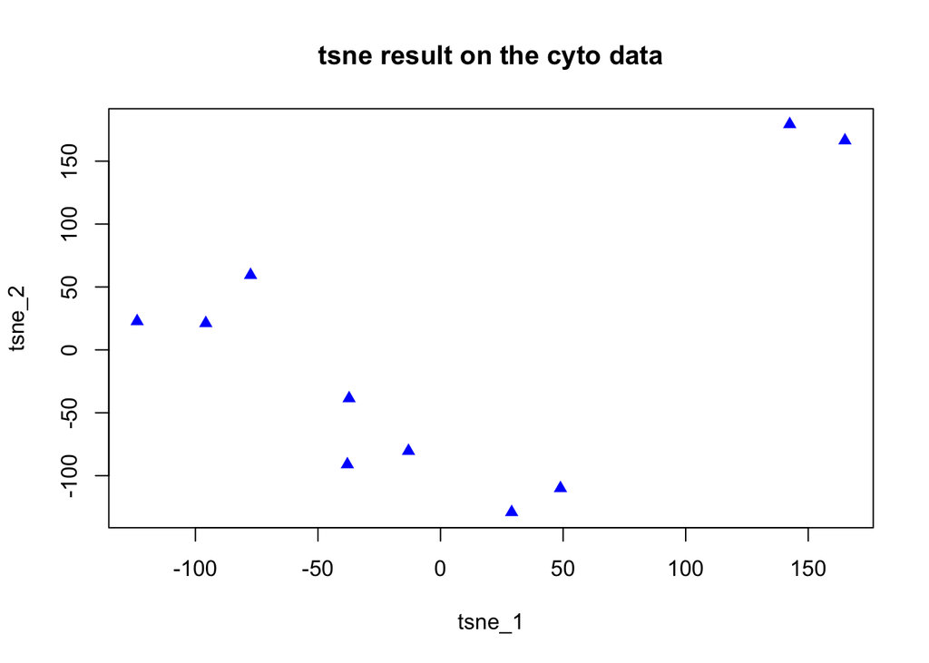

```r
plot(tsne$Y,
     xlab = "tsne_1",
     ylab = "tsne_2",
     main = "tsne result on the cyto data",
     pch = 17,
     col = "blue")
```

13. You can now save your plot in a pdf file

```r
pdf("fancy_plot.pdf")
plot(tsne$Y,
     xlab = "tsne_1",
     ylab = "tsne_2",
     main = "tsne result on the cyto data",
     pch = 17,
     col = "blue")
dev.off()
```

14. Plots that are too big can also be saved in a png format, they will however result in plots of lower quality. Knowing that the png function works exactly like the pdf function, export your figure in a png file:

```r
png("fancy_plot.png")
plot(tsne$Y,
     xlab = "tsne_1",
     ylab = "tsne_2",
     main = "tsne result on the cyto data",
     pch = 17,
     col = "blue")
dev.off()
```